Titanic Survival Exploration  
**By: Karan Vir Singh Bajaj**

# INDEX

| Index |  |
| --- | --- |
| Sno. | Particulars |
| 1 | Abstract |
| 2 | Summary |
| 3 | Problem Identification |
| 4 | Data Analysis |
| 5 | Conclusion |
| 6 | Limitations of the Analysis |
| 7 | References |

# ABSTRACT

The sinking of the RMS Titanic is one of the most infamous shipwrecks in history. On April 15, 1912, during her maiden voyage, the Titanic sank after colliding with an iceberg, killing 1502 out of 2224 passengers and crew. This sensational tragedy shocked the international community and led to better safety regulations for ships. This project Investigates the titanic's sample dataset consisting of 891 entries using Python, Numpy and Pandas for data wrangling and analysis and using matplotlib.pyplot library along with seaborn for data visualization in Ipython Notebook.

# SUMMARY

RMS Titanic was a British passenger liner that sank in the North Atlantic Ocean in the early morning of 15 April 1912, after colliding with an iceberg during her maiden voyage from Southampton to New York City. Of the 2,224 passengers and crew aboard, more than 1,500 died in the sinking, making it one of the deadliest commercial peacetime maritime disasters in modern history. The largest ship afloat at the time it entered service, the RMS Titanic was the second of three Olympic class ocean liners operated by the White Star Line, and was built by the Harland and Wolff shipyard in Belfast. Thomas Andrews, her architect, died in the disaster.

Under the command of Edward Smith, the ship carried some of the wealthiest people in the world, as well as hundreds of emigrants from Great Britain and Ireland, Scandinavia and elsewhere throughout Europe seeking a new life in North America. A high-power radiotelegraph transmitter was available for sending passenger "marconigrams" and for the ship's operational use. Although Titanic had advanced safety features such as watertight compartments and remotely activated watertight doors, there were not enough lifeboats to accommodate all of those aboard due to outdated maritime safety regulations. Titanic only carried enough lifeboats for 1,178 people—slightly more than half of the number on board, and one third of her total capacity.

This project Investigates the titanic's sample dataset consisting of 891 entries using Python programming language, Numpy and Pandas for data wrangling and data analysis and uses matplotlib library along with seaborn for data visualisation in Ipython Notebook. The scope of this project is to dive deeper into the data of the passenger, whether they survived or not, were males or females, minors or adults, their embarked location and passenger class etc. to identify what affected their chances of survival and how the variable were affected in relation to one another.

# PROBLEM IDENTIFICATION

1. **How did the individual characteristics affected the passenger's survival? And what was the relation of the Passenger Class(1st class, 2nd Class or 3rd Class) with other variables and the survival of the passengers?**

Variables: Age, Gender, Minor/Adult, Pclass.

2. **Was the passenger with or without a family(parent/siblings)? And did this affect their survival?**

Variables: With Parents, With Siblings

3. **What was the passenger's embarked location? And which Passenger class did they prefer?**

Variables: Pclass, embarked location

# DATA ANALYSIS

*Importing liabraries and packages and reading data (.csv)file*

```python
#import packages and liabraries

#importing unicodecsv to read and load the data file
import unicodecsv

#importing numpy as np
import numpy as np

#importing pandas as pd
import pandas as pd

#importing matplotlib.pyplot as plt
import matplotlib.pyplot as plt

#importing seaborn as sns
import seaborn as sns

#display code
from IPython.display import display

#matplot library holding in Ipyton Notebooks
%matplotlib inline
```

```python
#import titanic_data.csv dataframe through pandas inside titanic_data
titanic_data = pd.read_csv('titanic_data.csv')

#Displaying the small dataframe through the Head function
display(titanic_data.head())

print("")

#DataFrame Information
titanic_data.info()
```

|  | PassengerId | Survived | Pclass | Name | Sex | Age | SibSp | Parch | Ticket | Fare | Cabin | Embarked |
| --- | --- | --- | --- | --- | --- | --- | --- | --- | --- | --- | --- | --- |
| 0 | 1 | 0 | 3 | Braund, Mr. Owen Harris | male | 22.0 | 1 | 0 | A/5 21171 | 7.2500 | NaN | S |
| 1 | 2 | 1 | 1 | Cumings, Mrs. John Bradley (Florence Briggs Th... | female | 38.0 | 1 | 0 | PC 17599 | 71.2833 | C85 | C |
| 2 | 3 | 1 | 3 | Heikkinen, Miss. Laina | female | 26.0 | 0 | 0 | STON/O2. 3101282 | 7.9250 | NaN | S |
| 3 | 4 | 1 | 1 | Futrelle, Mrs. Jacques Heath (Lily May Peel) | female | 35.0 | 1 | 0 | 113803 | 53.1000 | C123 | S |
| 4 | 5 | 0 | 3 | Allen, Mr. William Henry | male | 35.0 | 0 | 0 | 373450 | 8.0500 | NaN | S |

```
<class 'pandas.core.frame.DataFrame'>
RangeIndex: 891 entries, 0 to 890
Data columns (total 12 columns):
PassengerId    891 non-null int64
Survived       891 non-null int64
Pclass         891 non-null int64
Name           891 non-null object
Sex            891 non-null object
Age            714 non-null float64
SibSp          891 non-null int64
Parch          891 non-null int64
Ticket         891 non-null object
Fare           891 non-null float64
Cabin          204 non-null object
Embarked       889 non-null object
dtypes: float64(2), int64(5), object(5)
memory usage: 83.6+ KB
```

*We can see that three columns are incomplete i.e. Age, Cabin and Embarked. When doing the analysis, we need to keep this in mind so that the results are not affected.*  
Age has 714 entries out of 891.  
Cabin has 204 entries out of 891.  
Embarked has 889 entries out of 891.

*As the "Name" and "Ticket" will not be required for the analysis, they will be dropped from the dataset and a modified dataset will be displayed and used for further Investigation. Reason: "Name" and "Ticket" will not affect the survival of the passengers. Though it might help in Identifying other information, but that is out of the scope of our Investigation.*

```python
#import titanic_data.csv dataframe through pandas inside titanic_data
titanic_data = pd.read_csv('titanic_data.csv')

#Displaying the small dataframe through the Head function
display(titanic_data.head())
```

|  | PassengerId | Survived | Pclass | Name | Sex | Age | SibSp | Parch | Ticket | Fare | Cabin | Embarked |
| --- | --- | --- | --- | --- | --- | --- | --- | --- | --- | --- | --- | --- |
| 0 | 1 | 0 | 3 | Braund, Mr. Owen Harris | male | 22.0 | 1 | 0 | A/5 21171 | 7.2500 | NaN | S |
| 1 | 2 | 1 | 1 | Cumings, Mrs. John Bradley (Florence Briggs Th... | female | 38.0 | 1 | 0 | PC 17599 | 71.2833 | C85 | C |
| 2 | 3 | 1 | 3 | Heikkinen, Miss. Laina | female | 26.0 | 0 | 0 | STON/O2. 3101282 | 7.9250 | NaN | S |
| 3 | 4 | 1 | 1 | Futrelle, Mrs. Jacques Heath (Lily May Peel) | female | 35.0 | 1 | 0 | 113803 | 53.1000 | C123 | S |
| 4 | 5 | 0 | 3 | Allen, Mr. William Henry | male | 35.0 | 0 | 0 | 373450 | 8.0500 | NaN | S |

```python
#DataFrame Information
titanic_data.info()
```

```
<class 'pandas.core.frame.DataFrame'>
RangeIndex: 891 entries, 0 to 890
Data columns (total 12 columns):
PassengerId    891 non-null int64
Survived       891 non-null int64
Pclass         891 non-null int64
Name           891 non-null object
Sex            891 non-null object
Age            714 non-null float64
SibSp          891 non-null int64
Parch          891 non-null int64
Ticket         891 non-null object
Fare           891 non-null float64
Cabin          204 non-null object
Embarked       889 non-null object
dtypes: float64(2), int64(5), object(5)
memory usage: 83.6+ KB
```

*We can see that three columns are incomplete i.e. Age, Cabin and Embarked. When doing the analysis, we need to keep this in mind.*  
Age has 714 entries out of 891.  
Cabin has 204 entries out of 891.  
Embarked has 889 entries out of 891.

*As the "Name" and "Ticket" will not be required for the analysis, they will be dropped from the dataset and a modified dataset will be displayed and used for further Investigation. Reason: "Name" and "Ticket" will not affect the survival of the passengers. Though it might help in Identifying other information, but that is out of the scope of our Investigation.*

```python
#Creating a Modified DataFrame

#Removed Name and Ticket column as they are not required for the Analysis.
titanic_data = titanic_data.drop(['Name','Ticket'], axis=1)

#Displaying Modified Dataframe
display(titanic_data.head())
```

|  | PassengerId | Survived | Pclass | Sex | Age | SibSp | Parch | Fare | Cabin | Embarked |
| --- | --- | --- | --- | --- | --- | --- | --- | --- | --- | --- |
| 0 | 1 | 0 | 3 | male | 22.0 | 1 | 0 | 7.2500 | NaN | S |
| 1 | 2 | 1 | 1 | female | 38.0 | 1 | 0 | 71.2833 | C85 | C |
| 2 | 3 | 1 | 3 | female | 26.0 | 0 | 0 | 7.9250 | NaN | S |
| 3 | 4 | 1 | 1 | female | 35.0 | 1 | 0 | 53.1000 | C123 | S |
| 4 | 5 | 0 | 3 | male | 35.0 | 0 | 0 | 8.0500 | NaN | S |

*The Table below shows the descriptive statistics of our modified data below that excludes "Name" and "Ticket".*

```python
#DataFrame Describe
titanic_data.describe()
```

|  | PassengerId | Survived | Pclass | Age | SibSp | Parch | Fare |
| --- | --- | --- | --- | --- | --- | --- | --- |
| count | 891.000000 | 891.000000 | 891.000000 | 714.000000 | 891.000000 | 891.000000 | 891.000000 |
| mean | 446.000000 | 0.383838 | 2.308642 | 29.699118 | 0.523008 | 0.381594 | 32.204208 |
| std | 257.353842 | 0.486592 | 0.836071 | 14.526497 | 1.102743 | 0.806057 | 49.693429 |
| min | 1.000000 | 0.000000 | 1.000000 | 0.420000 | 0.000000 | 0.000000 | 0.000000 |
| 25% | 223.500000 | 0.000000 | 2.000000 | NaN | 0.000000 | 0.000000 | 7.910400 |
| 50% | 446.000000 | 0.000000 | 3.000000 | NaN | 0.000000 | 0.000000 | 14.454200 |
| 75% | 668.500000 | 1.000000 | 3.000000 | NaN | 1.000000 | 0.000000 | 31.000000 |
| max | 891.000000 | 1.000000 | 3.000000 | 80.000000 | 8.000000 | 6.000000 | 512.329200 |

## 1. How did the Individual characteristics affected the passenger's survival?And what was the relation of the Passenger Class(1st class, 2nd Class or 3rd Class) with other variables and the survival of the passengers?

### **1.1 Passenger's Age Distribution**

*Age was an important for the survivability of the Passengers along with the Gender. The age should be Investigated as children were given a priority for lifeboats while evacuating the ship. We will Identify the age distribution of the passengers and how it affected the survivability.*

```
Youngest Passenger(years):
0.42

Oldest Passenger(years):
80.0

Average Age(years):
29.6991176471
```

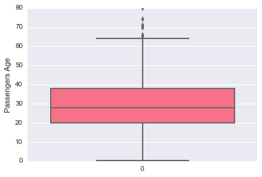

```python
#Identifying the age of the youngest passenger
print("Youngest Passenger(years): ")
youngest_passenger = titanic_data['Age'].min()
print(youngest_passenger)

print("")

#Identifying the age of the oldest passenger
print("Oldest Passenger(years): ")
oldest_passenger = titanic_data['Age'].max()
print(oldest_passenger)

print("")

#Identifying the Average age of the passengers
print("Average Age(years): ")
average_age = titanic_data['Age'].mean()
print(average_age)

print("")

#Creating a separate dataframe for the age of passengers inside age_passengers
age_passengers = titanic_data["Age"]

#Setting the Seaborn style to darkgrid
sns.set_style("darkgrid")

#Creating a boxplot for visualizing the data
sns.boxplot(data=age_passengers, palette="husl", saturation=1)

#Creating a boxplot for visualizing the data
passenger_age_boxplot = sns.boxplot(data=age_passengers, palette="husl", saturation=1)

#Naming Y axis as "Passenger's Age"
passenger_age_boxplot.set(ylabel='Passengers Age')
```

#### Distribution of Age in Passengers

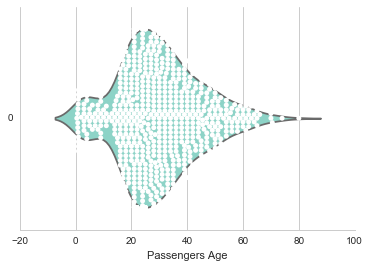

```python
#Setting Seaborn style to Whitegrid
sns.set_style("whitegrid")

#Creating a Violinplot for visualizing the distribution of age in passengers
passenger_age_violinplot = sns.violinplot(data=age_passengers, palette="Set3",
                                          saturation=1, inner=None, orient="h")

#Creating a swarn for visualizing the distribution of age in passengers
passenger_age_swarmplot = sns.swarmplot(data=age_passengers, color="w", orient="h")

#Naming x axis as "Passengers Age"
passenger_age_violinplot.set(xlabel='Passengers Age')

#Removing left spine
sns.despine(left=True)
```

*The Swarmplot above shows the representation of the data points of each passenger belonging to particular Age inside a violin plot.*

The chart above shows the distribution of each passenger on the basis of age inside the violin plot. We can clearly see that the maximum number of passengers's data points falling between the age group of 18 to 35 years which shows that the maximum number of people who were on board were of the age between 18 to 35 years.

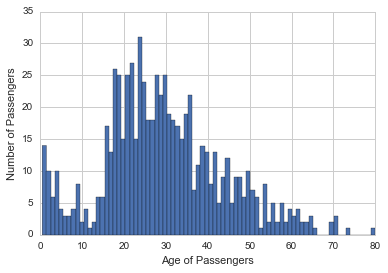

```python
#Creating a Histogram for visualizing the distribution of age in passengers
age_passengers_histogram = age_passengers.hist(bins=80)

#Naming Y axis as "Number of Passengers" and X axis as 'Age of Passengers'
age_passengers_histogram.set(ylabel='Number of Passengers', xlabel='Age of Passengers')
```

*The data represented on the Violinplot and the Histogram above shows us that the maximum number of people who were on board were of the age between 18 to 35 years with the youngest passenger being 0.42 years old, the oldest passenger being 80 years old and the average age being 29.69 years.*

The Histogram above shows the distribution of the number of passengers falling into each age group. The height of the bar represents the number of passengers in that particular age group. However, since we only have 714 entries for Age out of 891, this chart will only report 714 entries only and will not take into account the other entries.

#### Distribution of Age by Passenger Class

*According to the data, there were three types of class for Passengers.*  
1st Class  
2nd Class  
3rd Class

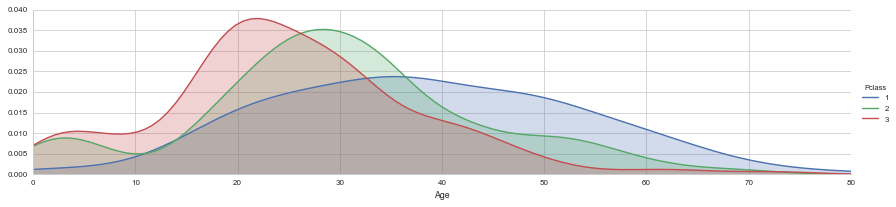

```python
#Creating a FacetGrid of the titanic_data with hue= Pclass
class_distribution = sns.FacetGrid(titanic_data, hue = 'Pclass', aspect=4, hue_order=[1,2,3])

#Mapping the KDEplot of Age with FacetGrid
class_distribution.map(sns.kdeplot,'Age',shade=True)

#Setting x-axis limit from age 0 to oldest passenger's age
class_distribution.set(xlim=(0, oldest_passenger))

#adding legends for representation
class_distribution.add_legend()
```

```python
#Giving the counts to each Pclass to identify total number of passengers in each class
titanic_data['Pclass'].value_counts()
```

```
3    491
1    216
2    184
Name: Pclass, dtype: int64
```

Using the Kernel Density Estimation(KDE) plot, we have split the age of the passengers into different Passenger classes where the blue color represents the age of the passengers in 1st passenger class, the green color represents the age in 2nd passenger class and the red color represents the 3rd passenger class.  
We can see that the majority of distribution of age in Pclass 3 is between 15 to 30 years, age in Pclass 2 is between 20 to 35 years and Pclass 1 has a diverse spread in the ages of the passengers from 10 to 70 years. Looking at information above, we can see that Pclass 1 has 216 passengers, Pclass 2 has the least passengers i.e. 184 and Pclass 3 has the maximum number of passengers i.e. 491.

### **1.2 Passenger Distribution by Gender**

Gender is considered as an important factor that could've affected the survival of the passengers. During emergencies, women and children are given a priority and considering this factor, during the sinking of the ship, women and children must have been considered as a priority for lifeboats than men. Now we will dive deeper into the gender distribution of the passengers to answer our question.

```python
#Creating specific dataframes for males and females

#Creating a specific male dataframe inside male_data dataframe
male_data = titanic_data[titanic_data.Sex == 'male']

#Creating a specific female dataframe inside female_data dataframe
female_data = titanic_data[titanic_data.Sex == 'female']
```

```python
#Display Total Males who were on Titanic
print('Males:' )
print(male_data.count()['Sex'])

print("")

#Display Total Females who were on Titanic
print('Females: ')
print(female_data.count()['Sex'])
```

```
Males:
577

Females:
314
```

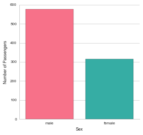

```python
#Creating a factor plot showing the distribution of males and females inside the dataframe gender_distribution_sex
gender_distribution_sex = sns.factorplot('Sex', data = titanic_data, kind = 'count', palette="husl", saturation=1)

#Labelling Y-axis with "Number of Passengers"
gender_distribution_sex.set_ylabels("Number of Passengers")
```

*Looking at the data and the chart above, we can clearly see that the number of male passengers were more than the number of female passengers on board.*

#### Gender Distribution by Passenger Class

Now we will distrbute the gender in different Pclasses which are classified on the basis of social and economic status i.e. representing Rich Class, Mediocre Class and Poor Class. Pclass 1 represents the Rich Class, Pclass 1 represents the mediocre class and Pclass 3 represents the poorest class.

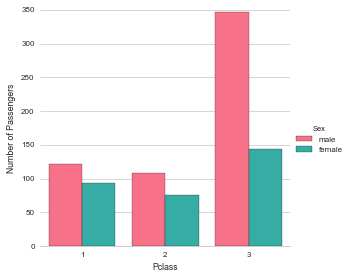

```python
#Creating a factorplot showing the distribution in Gender on the basis of Pclass
gender_distribution_sex = sns.factorplot('Pclass', order = [1,2,3], data = titanic_data, hue = 'Sex',
                                         kind = 'count', palette="husl", saturation=1)
#removing left spine
sns.despine(left=True)

#Setting Y labels to "Number of Passengers"
gender_distribution_sex.set_ylabels("Number of Passengers")
```

Looking at the chart above, we can see the distribution of Males and Females on the basis of Passenger Class. The males are dominant in all the three classes where the dominance is significant in Pclass 3. The distribution is almost equal in Pclass 2 and Pclass 1. The number of females passengers are maximum in Pclass 3 than the other two classes. This clearly shows that the number of passengers on board were higher in Pclass 3 than in Pclass 2 and Pclass 1.

### **1.3 Passenger Distribution by Minor/ Adult**

By the common law the age of majority is fixed at twenty-one years for both sexes, and, in the absence of any statute to the contrary, every person under that age, whether male or female, is an infant.

*-- The American and English Encyclopedia of Law, Garland and McGeehee, 1900*

By the common law, every person is, technically, an infant, until he is twenty-one years old; and, in legal presumption, is not of sufficient discretion to contract an obligation at an earlier age.

*-- English Common Law*

Now we will split the Age data into Minors (less than 21 years) and Adults (Greater than 21 years) to determine how many passengers were adults and how many were minors and if their survivability could be affected in this case as children had priority to lifeboats that could increase their chances of survival.

A function "minor_or_adult" is defined that will pull the age and sex data from our titanic_data and if the age is less than 21 then it will declare "minor" else it will declare "adult" under a separate column created in our dataframe by the name "status". This will help us in distinguishing the minors from the adults in a separate column and not overrite our existing dataframe.

```python
#Splitting the Age Data in 3 categories (child, adult male and adult female)
def minor_or_adult(passengers):
    age, sex = passengers

    if age < 21:
        return "minor"
    else:
        return sex

    #including new column to a data frame that distinguishes a passenger as a child or an adult
titanic_data['status'] = titanic_data[['Age', 'Sex']].apply(minor_or_adult, axis=1)
```

```python
#Displaying the modified dataframe that includes the column "status"
display(titanic_data.head(15))
```

|  | PassengerId | Survived | Pclass | Sex | Age | SibSp | Parch | Fare | Cabin | Embarked | status |
| --- | --- | --- | --- | --- | --- | --- | --- | --- | --- | --- | --- |
| 0 | 1 | 0 | 3 | male | 22.0 | 1 | 0 | 7.2500 | NaN | S | male |
| 1 | 2 | 1 | 1 | female | 38.0 | 1 | 0 | 71.2833 | C85 | C | female |
| 2 | 3 | 1 | 3 | female | 26.0 | 0 | 0 | 7.9250 | NaN | S | female |
| 3 | 4 | 1 | 1 | female | 35.0 | 1 | 0 | 53.1000 | C123 | S | female |
| 4 | 5 | 0 | 3 | male | 35.0 | 0 | 0 | 8.0500 | NaN | S | male |
| 5 | 6 | 0 | 3 | male | NaN | 0 | 0 | 8.4583 | NaN | Q | male |
| 6 | 7 | 0 | 1 | male | 54.0 | 0 | 0 | 51.8625 | E46 | S | male |
| 7 | 8 | 0 | 3 | male | 2.0 | 3 | 1 | 21.0750 | NaN | S | minor |
| 8 | 9 | 1 | 3 | female | 27.0 | 0 | 2 | 11.1333 | NaN | S | female |
| 9 | 10 | 1 | 2 | female | 14.0 | 1 | 0 | 30.0708 | NaN | C | minor |
| 10 | 11 | 1 | 3 | female | 4.0 | 1 | 1 | 16.7000 | G6 | S | minor |
| 11 | 12 | 1 | 1 | female | 58.0 | 0 | 0 | 26.5500 | C103 | S | female |
| 12 | 13 | 0 | 3 | male | 20.0 | 0 | 0 | 8.0500 | NaN | S | minor |
| 13 | 14 | 0 | 3 | male | 39.0 | 1 | 5 | 31.2750 | NaN | S | male |
| 14 | 15 | 0 | 3 | female | 14.0 | 0 | 0 | 7.8542 | NaN | S | minor |

```python
#Giving the count of number of male, female and child passengers on board inside the variable passenger_status_count
passenger_status_count = titanic_data['status'].value_counts()

#displaying passenger-status count
display(passenger_status_count)
```

```
male      474
female    237
minor     180
Name: status, dtype: int64
```

Using this function, we can see that the number of male adult passengers are still higher than the number of female adult passengers and minors. To determine the survivability on the basis of status, males and females under the age of 21 were grouped together under "minor" status.

#### Minor and Adult age distribution on the basis of status

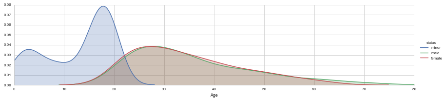

```python
#Creating a FacetGrid for titanic_data with hue= status
genger_status_distribution = sns.FacetGrid(titanic_data, hue='status', aspect=4,
                                           hue_order=['minor', 'male', 'female'])

#Mapping the KDEplot of Age with FacetGrid
genger_status_distribution.map(sns.kdeplot,'Age', shade=True)

#Setting x-axis limit from age 0 to oldest passenger's age
genger_status_distribution.set(xlim=(0,oldest_passenger))

#adding legends for representation
genger_status_distribution.add_legend()
```

With the help of the Kernel Density Estimation(KDE) plot, we can see the distribution of age in detail. The chart shows that adult males and adult females are distributed uniformally according to their age where maximum are in the age between 20 to 40 years. Looking at the Minor's age distribution, we can see two curves that represent age from infants to 10 years of age and the maximum number of minors of the age between 10 to 21 years.

#### Minor and Adult distribution by Class

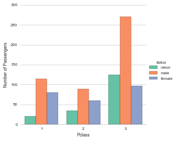

```python
# Creating Factor plot of Minor and Adult on the basis of Pclass
genger_status_class_distribution = sns.factorplot('Pclass', data=titanic_data, hue='status', kind='count',
                                                  order=[1,2,3], hue_order=['minor', 'male', 'female'],
                                                  palette='Set2', saturation=1)

#Removing left spine
genger_status_class_distribution.despine(left=True)

#Setting Y axis label to "Number of Passengers"
genger_status_class_distribution.set_ylabels("Number of Passengers")
```

The chart above shows the distribution of Minor, Adult Males and Adult Females in different Passenger Classes where Pclass 1 is the richest class and Pclass 3 is the poorest class. Looking at the distribution above, we can clearly see that males were dominant in all three classes and the 3rd class being the maximum. The majority of the population was in the poorest class i.e. Pclass 3 having the highest number of male adults, female adults and minors than the other two classes. Women are however almost uniformally distributed in all three classes, Pclass 3 being the maximum.

### Determining the Survivability

*Please Note: The Survivability on the basis of Gender will be determined through the survivability on the basis of status as it measures the survivability of male adults and female adults, as well as through the survivability on the basis of Age collectively when we explore the gender of the minor passengers.*

From the above analysis on different variables above, now we will determine the survivability of the passengers considering the variables : Age, Gender, Minor/Adult(status) and Pclass.

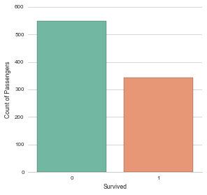

```python
#Modifying titanic_data and creating the column of Survivors containing information from Survived data
#From the survived data, stating 'No' for '0' which means death and 'Yes' for '1' which means survived.
titanic_data['Survivors'] = titanic_data.Survived.map({0:'No', 1:'Yes'})

#Creating a factorplot to visualize the number of passengers who died or survived
survivors_distribution = sns.factorplot('Survived', data=titanic_data, kind='count', palette='Set2')

#Removing left spine
survivors_distribution.despine(left=True)

#Labelling Y axis as "Count of Passengers"
survivors_distribution.set_ylabels("Count of Passengers")
```

*The chart above represents the distribution of the number of passengers who survived or died in the tragic incident. '0' represent 'deaths' and '1' represents 'survived'.*  
Looking at the chart above, we can see that more number of passengers died than the number of passengers who survived.

#### Survivability on the basis of Status (Minor/Adult)

Now we will determine the chances of survival of passengers on the basis on Status i.e. how their chances of survival were affected if they were minors, female adults or male adults.

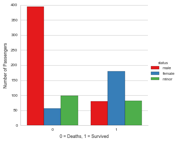

```python
#Creating a factorplot of the survival/death of the passengers on the basis of status
death_survival_sex = sns.factorplot('Survived', data = titanic_data, hue = 'status',
                                    kind = 'count', palette="Set1", saturation=2)

#Labeling X axis as 0 = Deaths, 1 = Survived
death_survival_sex.set_xlabels("0 = Deaths, 1 = Survived")


#Labeling Y axis as "Number of Passengers"
death_survival_sex.set_ylabels("Number of Passengers")
```

*The chart above represents the Death/Survival of the Passengers on the basis of status i.e. Adult male, Adult female or Minor. On the X-axis, 0 represents "Deaths" and 1 represents "Survived".*  
The chart clearly shows that the death in the adult male passengers was significantly higher than the death of the female adult passengers and minor passengers. The total deaths of the Minor passengers was also higer than the total deaths of the female adult passengers. The factors that can result in fewer deaths of female adults than minor could be that the minors of very small age were fewer and given a priority than the minors who were older. This can be determined by diving deeper into the age of the passengers and survival that we well see in the next chart.  
Looking at the survived bars on the chart, The total number of female adult survivors was higher than the total number of male adult survivors and the total number of minor survivors. Also, the survival bars for adult male survivors and minor survivors seem to be fairly equal.

```python
#Creating Seperate dataframe for passengers who were minor
Minor_Dataframe = titanic_data[titanic_data['status'] == "minor"]

#Creating Seperate dataframe for passengers who were female adults
Female_Adult_Dataframe = titanic_data[titanic_data['status'] == "female"]

#Creating Seperate dataframe for passengers who were male adults
Male_Adult_Dataframe = titanic_data[titanic_data['status'] == "male"]

#Creating list of minor passengers who survived
Minor_Survivor = Minor_Dataframe[Minor_Dataframe.Survivors == "Yes"]

#Creating list of female adult passengers who survived
Female_Adult_Survivor = Female_Adult_Dataframe[Female_Adult_Dataframe.Survivors == "Yes"]

#Creating list of male adult passengers who survived
Male_Adult_Survivor = Male_Adult_Dataframe[Male_Adult_Dataframe.Survivors == "Yes"]
```

*Above we have created specific dataframes for Minors, Female adults and Male adults. We have also created seperate lists for minor, female adult and male adult passengers who survived*  
Now we will determine the probability of the survival of minors, female adults and male adults and see whether there is any difference in the chances of survival.

```python
#Determining the probability of survival for Minor Passengers
Probability_Minor_Survived = float(Minor_Survivor['status'].count())
/ float(Minor_Dataframe['status'].count())

#Determining the probability of survival for Female Adult Passengers
Probability_Female_Survived = float(Female_Adult_Survivor['status'].count())
/ float(Female_Adult_Dataframe['status'].count())

#Determining the probability of survival for Male Adult Passengers
Probability_Male_Survived = float(Male_Adult_Survivor['status'].count())
/ float(Male_Adult_Dataframe['status'].count())
```

*Printing the probabilities of different passenger status and creating a factorplot to visualize it*

```
Probability of Survival of Minor:
0.455555555556

Probability of Survival of Female Adult:
0.759493670886

Probability of Survival of Male Adult:
0.168776371308
```

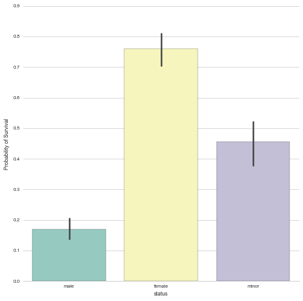

```python
#print probability of survival of Minor Passengers
print("Probability of Survival of Minor: ")
print(Probability_Minor_Survived)

print("")

#print probability of survival of Female Passengers
print("Probability of Survival of Female Adult: ")
print(Probability_Female_Survived)

print('')

#print probability of survival of Male Passengers
print("Probability of Survival of Male Adult: ")
print(Probability_Male_Survived)

print('')

#Creating a factorplot to visualize survival on the basis of status of the passengers
Survivors_status = sns.factorplot("status", "Survived", data=titanic_data, kind="bar", size=7, palette='Set3')

#Removimg left spine
Survivors_status.despine(left=True)

#leabeling Y axis as "probability of Survival"
Survivors_status.set_ylabels("Probability of Survival")
```

*The chart above shows the representation of the probability of survival of the passengers on the basis of status*  
Looking at the information and the chart above, we can clearly see that the probability of survival was higher for females than for males or minors. Females had about 75% chance of survival. The least chances of survival were for males, which is about 16% only. Minors chances of survival were about 45%, higher than the chances of males but lower than the chances of females. Though being a minor could be an important factor for survivability, one reason that could affect it and lead it to having lower chances of survivability than females could be the age distribution of minors that we will analyze below.

#### Survivability on the basis of Age

While analyzing the survivability of the passengers on the basis of their status above, we encountered a question of why the chances of survival of adult females was higher than the chances of survival of minors. We will into this question now and see how age may have affected the survivability of the passengers.

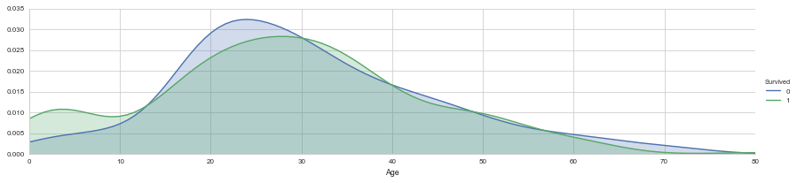

```python
#Creating a FacetGrid of titanic_data with hue = Survived
death_survival_age = sns.FacetGrid(titanic_data, hue = 'Survived', aspect=4)

#Mapping the KDEplot of Age with FacetGrid
death_survival_age.map(sns.kdeplot,'Age',shade=True)

#Setting x-axis limit from age 0 to oldest passenger's age
death_survival_age.set(xlim=(0, oldest_passenger))

#adding legends for representation
death_survival_age.add_legend()
```

*The KDE plot above shows the deaths and survival in the different age groups of the passengers who were on board. The blue curve indicates the density of Deaths and the green curve indicates the density of survivors.*  
Diving deeper to find the survivability on the basis of age, a KDE plot is considered for the analysis. Looking at the blue curve above, we can see that the maximum number of passengers who died were between the age of 12 to 45 years. The number of deaths is less for minor under the age of 10 years but increases significantly upto 21 years.  
Looking at the green plot having two curves, we can see that the maximum number of passengers who survived were between the age of 0.42 to 45 years. The chances of survival for minors under the age of 10 years was higher as depicted by the curve. However, there was no significant increase in the chances of survival for minors above the age of 10 years to 21 years as compared to other age groups.

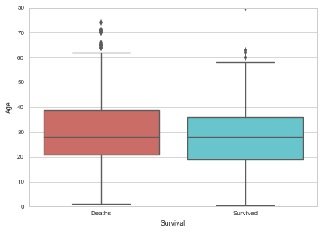

```python
#Creating a Box Plot with variable x as 'Survived' and y as 'Age' to determine how age affected survivability
Age_Distribution_Survival = sns.boxplot(data=titanic_data, x='Survived', y='Age',
                                        fliersize=5, whis=1.3, palette='hls')

#Setting Ylebels, Xlabels and Xticktables.
Age_Distribution_Survival.set(ylabel='Age', xlabel='Survival', xticklabels = ['Deaths', 'Survived'])
```

Now we will see the Age of the minors into small categories to determine the difference in survivability of minors who were younger and the survivability of the minors who were older. This is done in order to determine whether the chances of survival for a younger minor was different for the chances of survival for an older minor passenger. This will also give us an insight into why the probability of survival of female adults passengers was more that the probability of survival of minor passengers.  
Though one another reason that could have led to a lower probability of survival for minor passengers than the female adults could be the distribution of gender of the minors and whether one gender would've got the priority of lifeboats than other in the minor passenger group as well as the count of each gender group who were minors.

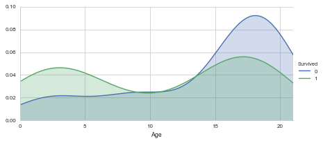

```python
#Creating a FacetGrid of Minor_Dataframe with hue="survived"
Survivability_minor_age = sns.FacetGrid(Minor_Dataframe, hue = 'Survived', aspect=2)

#Mapping KDEplot of Age with FacetGrid
Survivability_minor_age.map(sns.kdeplot,'Age',shade=True)

#Setting x-axis limit from age 0 to 21 years
Survivability_minor_age.set(xlim=(0, 21))

#adding legends for representation
Survivability_minor_age.add_legend()
```

*The Kernel Density Estimation(KDE) plot above, represents the survivability of the minor passengers on different levels of age. The green curve represents 'Survived' and the blue curve represents 'Death'.*

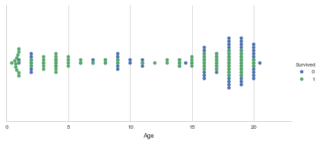

```python
#Creating a FacetGrid of the Minor_dataframe with hue="Survived"
Survivability_minor_age = sns.FacetGrid(Minor_Dataframe, hue='Survived', aspect=2)

#Mapping the KDEplot of Age with FacetGrid and data= Minor_dataframe
Survivability_minor_age.map(sns.swarmplot,'Age',  data=Minor_Dataframe)



#Setting x-axis limit from age 0 to 23 years
Survivability_minor_age.set(xlim=(0, 23))

#adding legends for representation
Survivability_minor_age.add_legend()
```

*The Swarmplot above, represents the survivability of the minor passengers on different levels of age. The blue dots represent 'Deaths' and green dots represent 'Survived'.*

Looking at the KDEplot as well as swarmplot above, we can clearly see that the minors below the age of 6 years had more chances of survival than the minors above the age of 6 years. Analyzing the swarmplot above, we can see that there were more deaths in minor passengers from age 16 years and above than the ages below. Also looking at the distribution, we can see that number of minors between the age of 0.42 to 5 years and number of minors in the age group of 16 years and above were more than the number of minor passengers between the age of 5 to 15 years.

*Now we will see how the survivability of male and female minor passengers on different levels of Age. The blue dots represent 'Survived' and red dots represent 'Death'.*

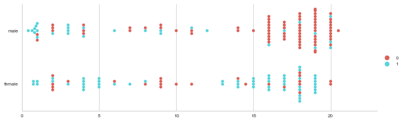

```python
#Creating a FacetGrid with Minor_Dataframe
Survivability_minor_age_sex = sns.FacetGrid(Minor_Dataframe, aspect=3)

#Mapping the KDEplot of x = Age, y = sex and hue = Survived with FacetGrid
Survivability_minor_age_sex.map(sns.swarmplot, x='Age',y='Sex', hue='Survived',
                                data=Minor_Dataframe, size=5, palette='hls')



#Setting x-axis limit from age 0 to 23 years
Survivability_minor_age_sex.set(xlim=(0, 23))

#adding legends for representation
Survivability_minor_age_sex.add_legend()
```

Looking at the swarm plot above, we can see the distribution of minor passengers who survived or died at different levels of age in both the genders. The chart shows that the minor male passengers were more in number than the minor female passengers. Also the number of deaths can be seen more in number in minor male passengers than in minor female passengers. Therefore, the inference made earlier whether the gender could be a reason for why the probability of survival of minor male passengers was lower than the probability of survial of female adult passengers can be declared True. This is because looking at the chart, between the age group of 15 to 20 years, we can see that more males died and more females survived. We can say that in the case older minors, female minor passengers were given a priority for lifeboats than male minor passengers.

*Now we will see the survivability of all the male and female passengers on different levels of Age. The blue dots represent 'Survived' and red dots represent 'Death'. We will also determine whether the youngest and the oldest passenger survived or died and whether they were male or female.*

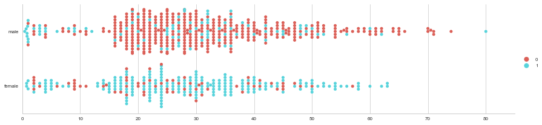

```python
#Creating a FacetGrid with titanic_data
Survivability_passenger_age_sex = sns.FacetGrid(titanic_data, aspect=4)

#Mapping the KDEplot of x = Age, y = Sex and hue = Survived with FacetGrid
Survivability_passenger_age_sex.map(sns.swarmplot, x='Age',y='Sex', hue='Survived',
                                    data=titanic_data, size=5, palette='hls')



#Setting x-axis limit from age 0 to 85 years
Survivability_passenger_age_sex.set(xlim=(0, 85))

#adding legends for representation
Survivability_passenger_age_sex.add_legend()
```

Looking at the chart above, we can see that the survivability in males was not significantly affected by the age i.e. after the age of 13 or 15 years, Age in males did not play a very important factor in receiving the priority for lifeboats which could have increased their chances of survival. Though looking at the age below 13 years, age played a factor in the survival of the minors below 13 years. However, in the case of females, even there the age does not seem to play a very important role as the deaths are almost equally scattered along the ages but, the factor of gender did play an important role in determining the survivability and priority to lifeboats and females, irrespective of age were given priority to lifeboats more than men and survived.  
Looking at both ends of the chart, we can see that the youngest passenger and the oldest passenger were both males and both of them survived. However, as we do not have the population data and are doing the on the sample data of 891 entries out of 2224, it will be difficult to say whether the youngest passengger and oldest passenger was a male or a female and whether they survived or not.

#### Survivability on the basis of Pclass

*Now we will determine the survivability on the basis of each PassengerClass(Pclass) i.e. First Class, Second Class and Third Class.*

```python
#Giving the counts to each Pclass to identify total number of passengers in each class
titanic_data['Pclass'].value_counts()
```

```
3    491
1    216
2    184
Name: Pclass, dtype: int64
```

*The data above shows the total number of passengers in each class who were on board.*

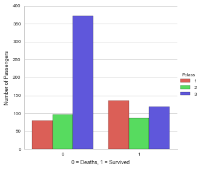

```python
#Creating a factorplot of the survival/death of the passengers on the basis of Passenger Class
death_survival_sex_Pclass_bar = sns.factorplot('Survived', data = titanic_data, hue = 'Pclass',
                                               kind = 'count', palette="hls", saturation=2)

#Labeling X axis as 0 = Deaths, 1 = Survived
death_survival_sex_Pclass_bar.set_xlabels("0 = Deaths, 1 = Survived")

#Labeling Y axis as "Number of Passengers"
death_survival_sex_Pclass_bar.set_ylabels("Number of Passengers")
```

Now we will determine the probability of survival of passengers on the basis of Pclass.  
*Creating seperate dataframes and lists for each Pclass and it survivors*

```python
#Creating Seperate dataframe for passengers who were in Pclass 1
Pclass1_Dataframe = titanic_data[titanic_data['Pclass'] == 1]

#Creating Seperate dataframe for passengers who were in Pclass 2
Pclass2_Dataframe = titanic_data[titanic_data['Pclass'] == 2]

#Creating Seperate dataframe for passengers who were in Pclass 3
Pclass3_Dataframe = titanic_data[titanic_data['Pclass'] == 3]

#Creating list of Pclass1 survivors
Pclass1_Survivor = Pclass1_Dataframe[Pclass1_Dataframe.Survivors == "Yes"]

#Creating list of Pclass2 survivors
Pclass2_Survivor = Pclass2_Dataframe[Pclass2_Dataframe.Survivors == "Yes"]

#Creating list of Pclass3 survivors
Pclass3_Survivor = Pclass3_Dataframe[Pclass3_Dataframe.Survivors == "Yes"]
```

*Now we will find the probability of survival of passengers in each Pclass and analyze whether there is any difference or whether the type of Pclass has affected the chances of survival.*

```python
#Determining the probability of Pclass1 survivors
Probability_Pclass1_Survivors = float(Pclass1_Survivor['Pclass'].count()) / float(Pclass1_Dataframe['Pclass'].count())

#Determining the probability of Pclass2 survivors
Probability_Pclass2_Survivors = float(Pclass2_Survivor['Pclass'].count()) / float(Pclass2_Dataframe['Pclass'].count())

#Determining the probability of Pclass3 survivors
Probability_Pclass3_Survivors = float(Pclass3_Survivor['Pclass'].count()) / float(Pclass3_Dataframe['Pclass'].count())
```

*Printing the probabilities of survival of passengers in each Pclass and creating a factor plot to visualize the data.*

```
Probability of Survival for Pclass1:
0.62962962963

Probability of Survival for Pclass2:
0.472826086957

Probability of Survival for Pclass3:
0.242362525458
```

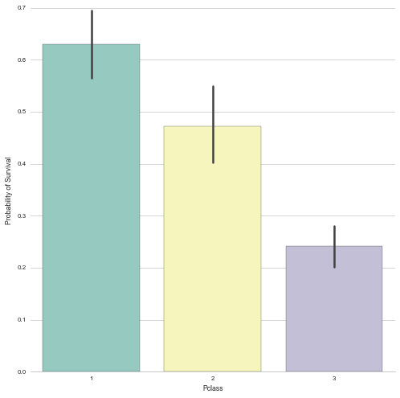

```python
#print probability of Pclass1 Survivors
print("Probability of Survival for Pclass1: ")
print(Probability_Pclass1_Survivors)

print("")

#print probability of Pclass2 Survivors
print("Probability of Survival for Pclass2: ")
print(Probability_Pclass2_Survivors)

print('')

#print probability of Pclass3 Survivors
print("Probability of Survival for Pclass3: ")
print(Probability_Pclass3_Survivors)

print('')

#Creating a factorplot to visualize survival on the basis of Pclass of the passengers
Survivors_status = sns.factorplot("Pclass", "Survived", data=titanic_data, kind="bar", size=7, palette='Set3')

#Removimg left spine
Survivors_status.despine(left=True)

#leabeling Y axis as "probability of Survival"
Survivors_status.set_ylabels("Probability of Survival")
```

*This chart represents the visualization of the probabilities of survival of passengers in each Pclass.*

Looking at the chart above, we can see that the maximum chances of survival of the passengers were in Pclass 1 which was the rich class. The probability was about 62% followed by 47% in Pclass 2. Pclass 3 which was the poorest class had the probability of only 24% of survival of the passengers who were in this class. This shows that the type of class effected the chance of survival and priority to the lifeboats. The class with the rich passengers were given priority to the lifeboats and survived thereby having a higher survival chance than the class with poor passengers were not given a priority to lifeboats and thereby havign a lower chance of survival.

## 2. Was the passenger with or without a family(parent/siblings)? And did this affect their survival?

### **2.1 Passenger Distribution with or without family**

*Another important factor to consider is whether the passenger was with or without the family that could have increased or decreased their chances of survival.*

```python
#Pulling .Parch(Parents or children on Board) and .SibSp(siblings on board) inside a new column With or without Family
titanic_data['With or without Family'] = titanic_data.SibSp + titanic_data.Parch

#Determining if passengers were alone or with family
titanic_data['With or without Family'].loc[titanic_data['With or without Family'] > 0] = 'With Family'
titanic_data['With or without Family'].loc[titanic_data['With or without Family'] == 0] = 'Without Family'

#displaying the dataframe
display(titanic_data.head())
```

|  | PassengerId | Survived | Pclass | Sex | Age | SibSp | Parch | Fare | Cabin | Embarked | status | With or without Family | Survivors |
| --- | --- | --- | --- | --- | --- | --- | --- | --- | --- | --- | --- | --- | --- |
| 0 | 1 | 0 | 3 | male | 22.0 | 1 | 0 | 7.2500 | NaN | S | male | With Family | No |
| 1 | 2 | 1 | 1 | female | 38.0 | 1 | 0 | 71.2833 | C85 | C | female | With Family | Yes |
| 2 | 3 | 1 | 3 | female | 26.0 | 0 | 0 | 7.9250 | NaN | S | female | Without Family | Yes |
| 3 | 4 | 1 | 1 | female | 35.0 | 1 | 0 | 53.1000 | C123 | S | female | With Family | Yes |
| 4 | 5 | 0 | 3 | male | 35.0 | 0 | 0 | 8.0500 | NaN | S | male | Without Family | No |

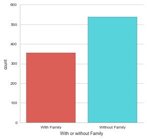

```python
#Creating a factorplot to determine the number of passengers with and without family
sns.factorplot('With or without Family', data=titanic_data, palette='hls', kind='count', saturation=2)
```

*Looking at the chart above, we can see that more people were on board without a family (parents or siblings).*

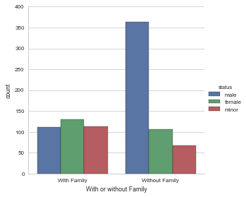

```python
#Creating a facotrplot showing the distribution of status in the passengers who were with or without family
with_without_family_status = sns.factorplot('With or without Family', data=titanic_data ,hue='status', kind='count')
```

*The chart above represents the distribution distribution of the status of the passengers on board and the count of how many of them were with or without their family(siblings or parents).*  
Looking at the chart above we can see that the maximum number of male adults were without the family than the female adults and minors. We can also see than some minor passengers were also on board without their family. The distribution on the left shows that the count of family members who were on board for adult males, adult females and minors were fairly equal.

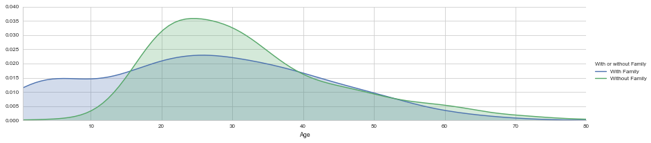

```python
#Creating a FacetGrid of the With or without Family data inside separate dataframe named with_without_Age
with_without_Age = sns.FacetGrid(titanic_data, hue = 'With or without Family', aspect=4)

#Mapping the KDEplot of Age with FacetGrid
with_without_Age.map(sns.kdeplot,'Age',shade=True)

#Setting x-axis limit from age 0 to oldest passenger's age
with_without_Age.set(xlim=(youngest_passenger, oldest_passenger))

#adding legends for representation
with_without_Age.add_legend()
```

*The chart above represents the distribution of family accompanies passengers on board on the basis of passenger's age*  
Looking at the KDE plot above, we can see one blue color curve that represents the passengers who were with family and a green color curve that represents the passengers who were on board without family.  
The blue color curve shows that minors below the age of 10 were accompanied by their family members and even with the minors from age 10 to 21. However the green color curve also shows that some minors even below the age of 10 were not accompanied by their family. The maximum number of passengers who were with the family members were from the age group of 0.42 to 40 years and the maximu number of passengers who were without the family members were from the age group of 15 to 40 years.

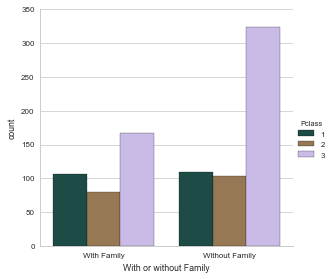

```python
#Creating a facotrplot showing the distribution of with or without family passengers on the basis of Pclass
with_without_family_Pclass = sns.factorplot('With or without Family', data=titanic_data ,
                                            hue='Pclass', kind='count', palette='cubehelix')
```

*The chart above represents the distribution of passengers who were with or without family members on the basis of Pclass*  
Looking at the chart above, we can see that the maximum number of passengers who were without a family were significantly higher in Pclass 3 which was the poorest class whereas the other two classes had fairly equal passengers who were without family members.  
Looking on the bars that represent the number of passengers who were without family members, we can clearly see that again passengers in Pclass 3 were more in number who were with their family members, followed by passengers in Pclass 1 which was the rich class.

### Survivability of Passengers travelling with or without family members

*Now we will determine the survivability of the Passengers travelling with or without family members and see whether there was any difference between the chances of survival for passengers travelling with family than the passengers travelling without the family.*

```
Probability of Survival with Family:
0.505649717514

Probability of Survival without:
0.303538175047
```

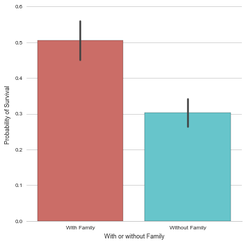

```python
#Creating Seperate dataframe for passengers travelling with family
Passengers_with_family = titanic_data[titanic_data['With or without Family'] == "With Family"]

#Creating Seperate dataframe for passengers travelling without family
Passengers_without_family = titanic_data[titanic_data['With or without Family'] == "Without Family"]

#Creating list of passengers with family who survived
Survived_with_family_passengers = Passengers_with_family[Passengers_with_family.Survivors == "Yes"]

#Creating list of passengers without family who survived
Survived_without_family_passengers = Passengers_without_family[Passengers_without_family.Survivors == "Yes"]

#Determining the probability of survival for passengers with family
Probability_Survived_with_family = float(Survived_with_family_passengers['With or without Family'].count())
/ float(Passengers_with_family['With or without Family'].count())

#Determining the probability of survival for passengers without family
Probability_Survived_without_family = float(Survived_without_family_passengers['With or without Family'].count())
/ float(Passengers_without_family['With or without Family'].count())

#print probability of survival with family
print("Probability of Survival with Family: ")
print(Probability_Survived_with_family)

print("")

#print probability of survival without family
print("Probability of Survival without: ")
print(Probability_Survived_without_family)

print('')

#Create a factorplot to visualize survival on the basis of passengers with out without family
Survivors_with_without_family = sns.factorplot("With or without Family", "Survived", data=titanic_data,
                                               kind="bar", size=5, palette='hls')

#Removimg left spine
Survivors_with_without_family.despine(left=True)

#leabeling Y axis as "probability of Survival"
Survivors_with_without_family.set_ylabels("Probability of Survival")
```

*The information and the chart above shows the probability of the survival of passenger who were with and without their family*  
*Above we have created separate dataframes for passengers travelling with and without the family and created separate lists for passengers who survived who were with and without family respectively. The probability was determined for the survival of passengers who were with the family and without the family and the data was plotted on the graph for visualization and analyzing the difference.*

Looking at the data and chart above, we can see that the chances of survival of passengers with family was 50% where as the chances of survival of passengers without family was 30%. This shows that the passengers with family had more chances of survival than the passengers without family members on board.

## 3. What was the passenger's embarked location? And which Passenger class did they prefer?

### 3.1 Passenger Distribution on the basis of Embarked Location

*Now we will determine the distribution of passengers on the basis of their embarked location i.e. either from Southampton, Cherbourg and Queenstown.*

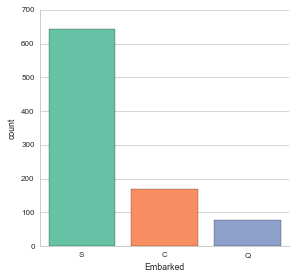

```python
#Creating a factorplot showing the distribution of passengers on the basis of different embarked locations
sns.factorplot('Embarked', data=titanic_data, palette='Set2', kind='count', saturation=2)
#Removing left spine
sns.despine(left=True)
```

*The chart above shows the distribution of passengers on the basis of Embarked Location i.e. from where they embarked the ship - Southampton, Cherbourg or Queenstown.*

Looking at the chart above we can see that the maximum number of passengers boarded the ship from Southampton(S) followed by Cherbourg(C) and finally Queenstown(Q)

### 3.2 Passenger Distribution on the basis of Pclass they preferred from each location

*Now we will see the distribution of passengers of different embarked locations on the basis of the Pclass they preferred.*

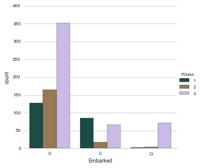

```python
#Creating a factorplot showing the distribution passengers in different Pclasses embarked from different locations
sns.factorplot('Embarked', data=titanic_data, hue='Pclass', kind='count', palette="cubehelix")
#Removing left spine
sns.despine(left=True)
```

Looking at the chart above, we can see that the maximum number of Passengers boarded the ship from Southampton(S) and stayed in Pclass 3 which was the poorest class followed by Pclass 2 and Pclass 1 respectively.  
From Cherbourg(C), maximum number of passengers stayed in Pclass 1, followed by Pclass 3 and Pclass 2 respectively.  
From Queenstown(Q), maxium number of passengers stayed in Pclass 3, followed by Pclass 2 and Pclass 1 respectively.

### Survivability on the basis of Embarked Location

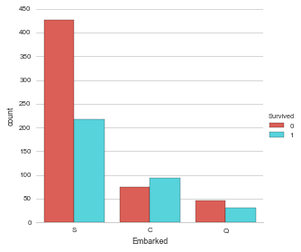

```python
#Creating a factorplot showing the Survivability on the basis of different embarked locations
sns.factorplot('Embarked', data=titanic_data, hue='Survived', palette='hls', kind='count', saturation=2)
#Removing left spine
sns.despine(left=True)
```

*The chart represents the distribution of the number of passengers who survived/ died and were from which embarked locations*

Looking at the chart above, we can see that the maximum number of passengers who died and survived respectively, embarked the ship from Southampton(S), followed by Cherbourg(C) and Queenstown(Q).

# CONCLUSION

Gender was an important factor that affected the survivability of the passengers significantly. During emergencies, women and children were given a priority and considering this factor, during the sinking of the ship, women and children were given priority for lifeboats than men. Age was a factor too that affected the survivability but not as important as gender. Age played an important role for minor passengers under the age of 13 - 15 years. However, from 15 years, age didnt increased or decresed the chances of survival of the passengers and that was one of the reasons why the chances of survival of female adults was more than the survival of the minors.  
The passenger class also played a very important role in determining the survivability of the passengers. The maximum number of passengers were in Pclass 3 which was the poorest class followed by Pclass 1 which was considered a rich class. The chances of survival for passengers in Pclass 1 were much higher than the chances of survival of passengers in Pclass 2 or 3. This showed that the Rich passengers were given a priority for lifeboats than the poor passengers on board.  
Many passengers were on board without a family, maximum being the males between the age of 18 to 35 years who stayed in Pclass 3. The probability of survival of passengers with family was about 50% whereas the probability of survival of passengers without a family was about 30%. The people who were accompanied by their parents or siblings, did had a higher chance of survival.

# LIMITATIONS OF THE ANALYSIS

1) The data analysis and results are based on the sample data consisting of 891 entries where as the total number of passengers on board were 2224 so the actual results can vary.  
2) The data is not fully complete. Columns like Age, Cabin and Embarked had NaN values which can make the actual results differ from the results generated.  
3) Other family relatives were excluded from this study include cousins,nephews/nieces, aunts/uncles, and in-laws. Some children travelled only with a nanny, therefore parch=0 for them. As well, some travelled with very close friends or neighbors in a village, however, this thing was not taken into account.

# REFERENCES

- https://www.kaggle.com/c/titanic/data
- https://en.wikipedia.org/wiki/RMS_Titanic
- http://pandas.pydata.org/pandas-docs/stable/indexing.html
- https://stanford.edu/~mwaskom/software/seaborn/index.html
- https://www.kaggle.com/c/titanic/details/getting-started-with-python-ii
- https://campus.datacamp.com/courses/intro-to-python-for-data-science
- https://stanford.edu/~mwaskom/software/seaborn/tutorial/aesthetics.html?highlight=aesthetics
- http://history.stackexchange.com/questions/17481/what-was-the-age-of-majority-in-1900-united-states
- https://stanford.edu/~mwaskom/software/seaborn/generated/seaborn.factorplot.html?highlight=factorplot
- https://stanford.edu/~mwaskom/software/seaborn/generated/seaborn.swarmplot.html?highlight=swarmplot
- https://stanford.edu/~mwaskom/software/seaborn/generated/seaborn.kdeplot.html?highlight=kdeplot#seaborn.kdeplot